# College Basketball Data Analysis

Xixi

2022-12-30

# INTRODUCTION

Basketball has been one of the most popular sports and also one of the most analyzed sports through [notational analysis](https://www.ncbi.nlm.nih.gov/pmc/articles/PMC3661887/). As a result, game-related data analyses are very popular among coaches, players, and even sports fans and have been used to improve understanding of basketball game performance.

This paper will focus on solving the two questions related to the two variables in our dataset: Do the basketball levels differ between `Conferences`? If so, what may cause the differences? And how can we predict a team’s `Seed` based on its existing basketball game performance data of the regular season?

Our analysis aims to identify the basketball performance indicators which help the team ace in the regular season and assist the coaches in designing targeted training programs, improving teams’ competitiveness.

# DATA

My analysis was done on the data from [Kaggle](https://www.kaggle.com/datasets/andrewsundberg/college-basketball-dataset?select=cbb19.csv) named College Basketball Dataset by Andrew Sunberg. The data is from the 2013, 2014, 2015, 2016, 2017, 2018, 2019, 2020, and 2021 Division I college basketball seasons. Due to Covid-19, there was no postseason for the 2020 season’s data set, so I did not include the data from 2020 in my analysis. I added a `YEAR` column to each dataset from 2013 to 2021, except 2020. I also created a `W_ratio` column, which is the total winning games to the total number of games played for a specific team in the regular of a particular year. Then I combined all the datasets to form a combined dataset named *cbb_all*. For the convenience of performing the quantitative calculation, I intended to convert the professional expressions in the `POSTSEASON` into numbers: *R68* to *68*, *R64* to *64*, *R32* to *32*, *S16* to *16*, *E8* to *8*, *F4* to *4*, *2ND* to *2*, and *Champions* to *1*.

I will interpret all the variables in the modified dataset in the following table:

College Basketball Dataset

[output not shown]

# RESULTS

> Question 1: Do the basketball levels differ between `Conferences`? If so, what may cause the differences?

For a person who doesn’t know much about basketball, the indicators to measure a basketball team’s level are the `SEED` at the end of the postseason and the ranking in the finals, the `POSTSEASON` in our dataset. Unfortunately, since we currently don’t have the performance data of the postseason (we only have the results), it is nearly impossible to perform the analysis. In this manner, I chose to focus on the `SEED` and wanted to explore the patterns behind it. I counted the total number of teams in each `SEED` from 2013 to 2021 (excluding 2020) and grouped them by `CONF` (Conference). It is worth mentioning that I filtered all the *NA* values because they were not significant. I utilized a *tile plot*, and the numbers on the tile represent the number of teams in the specific `SEED` of a particular `CONF`. For example, the bottom left corner tile demonstrates that *ACC has total 9 teams in Seed 1 from 2013 to 2021 (excluding 2020)*. The darker the color of the tile, the larger the number of teams of the conference in the seed. We know that the team getting *Seed 1* is more competitive than that gets *Seed 2*, and the team getting *Seed 2* is more competitive than that gets *Seed 3*, etc. Thus, conferences with higher basketball levels have more teams in the top seeds, *Seed 1*, *Seed 2*, *Seed 3*, and *Seed 4*, having greater chances of reaching the finals.

```
## replace the existing one.
```

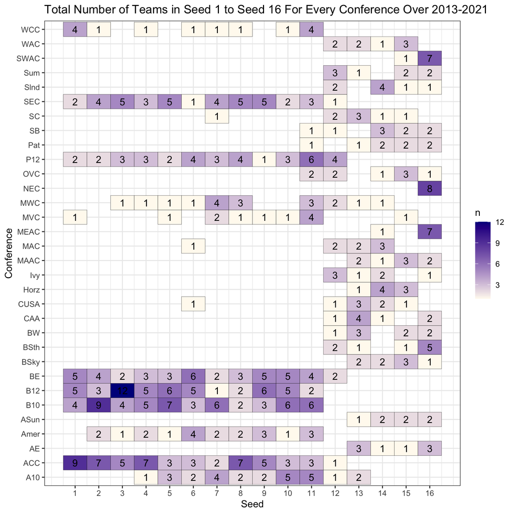

Based on the colors and numbers of the tile plot, conferences ACC, B10, B12, and BE have an absolute advantage in reaching the top seeds, while conferences MEAC, NEC, and SWAC are less competitive in more likely to get *SEED 16*. Additionally, conference GWC and Ind group (independent teams) are not even on the plot, which indicates that they never made it to the finals. Thus, we can roughly conclude that conferences like ACC, B10, and B12 are of higher basketball level than conferences like MEAC, NEC, SWAC, and GWC.

To explore the reasons for the differences in `SEED`, I implemented boxplots to illustrate the distribution of the game performance indicators among conferences. I will specifically talk about the characteristic ones in the following:

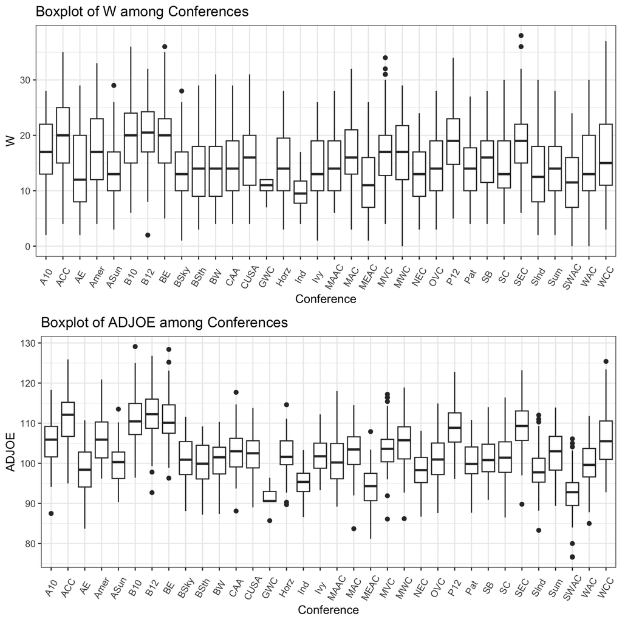

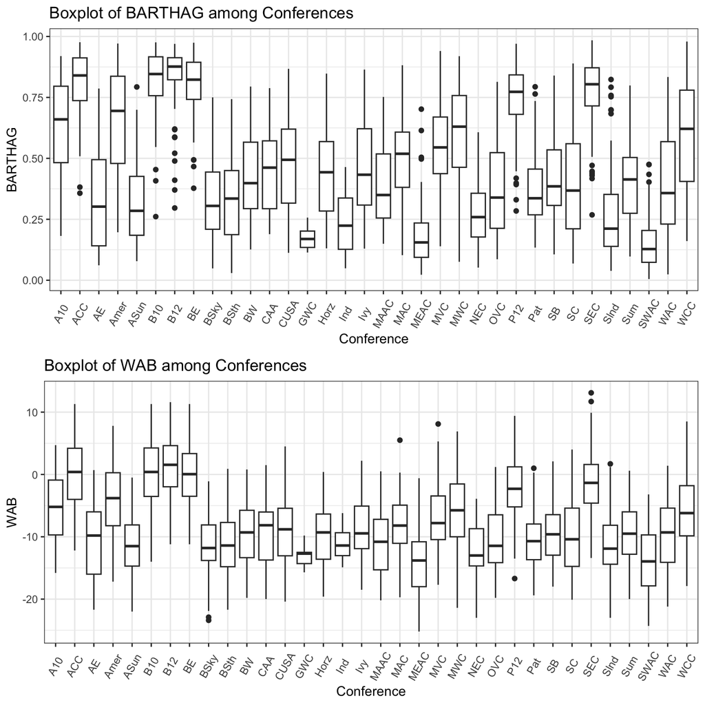

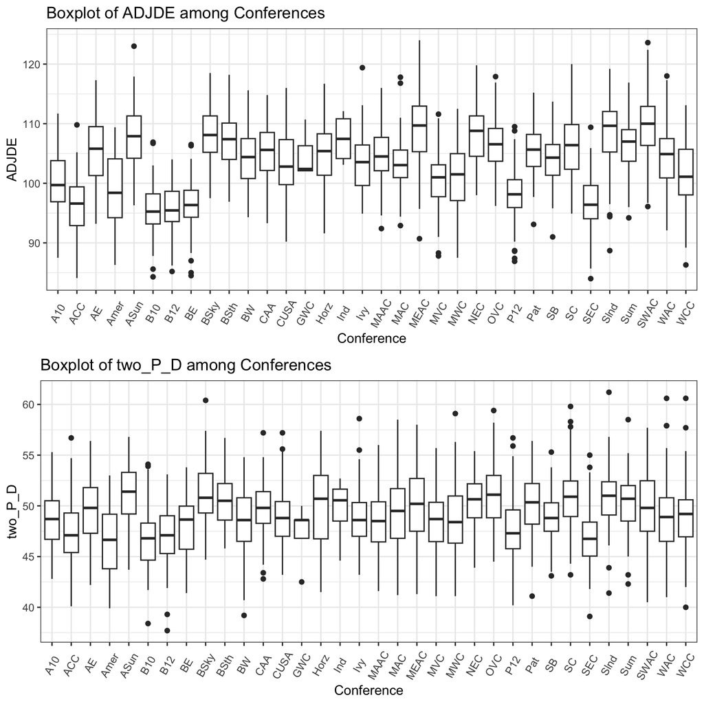

Among these 6 boxplots, conferences ACC, B10, B12, and BE are likely to have higher values in `W`, `ADJOE`, `BARTHAG`, and `WAB` than other conferences shown in the first 4 boxplots while having lower values in `ADJDE` and `two_P_D` than other conferences in the last 2 boxplots.

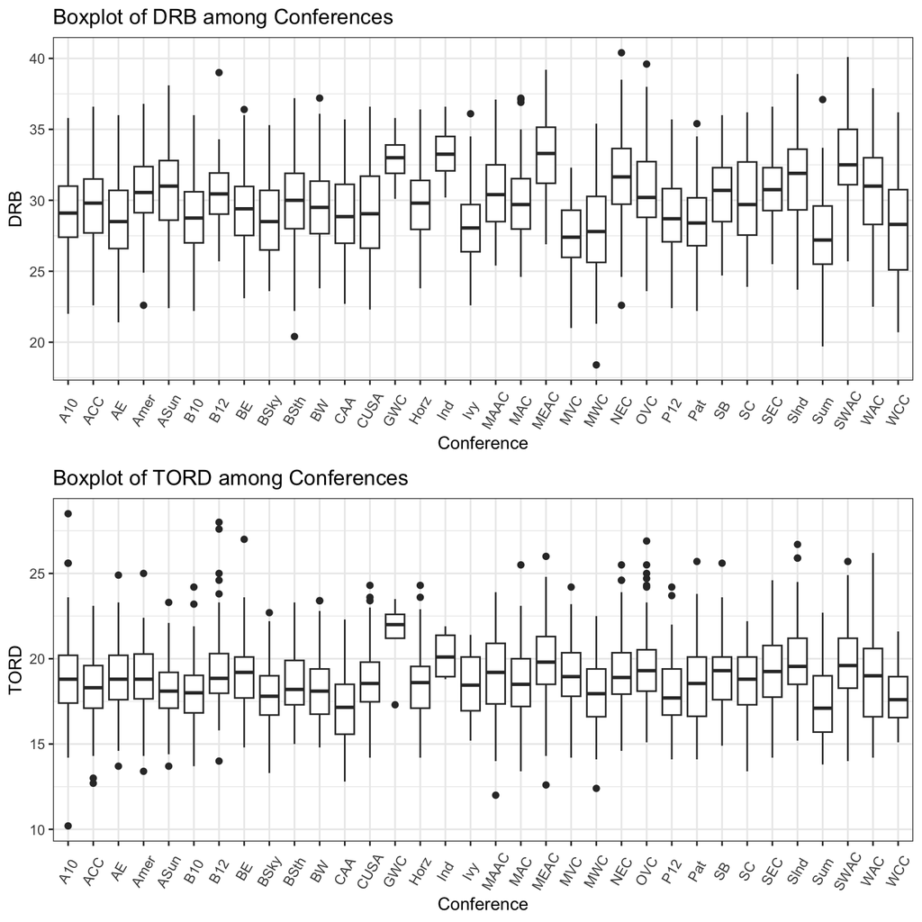

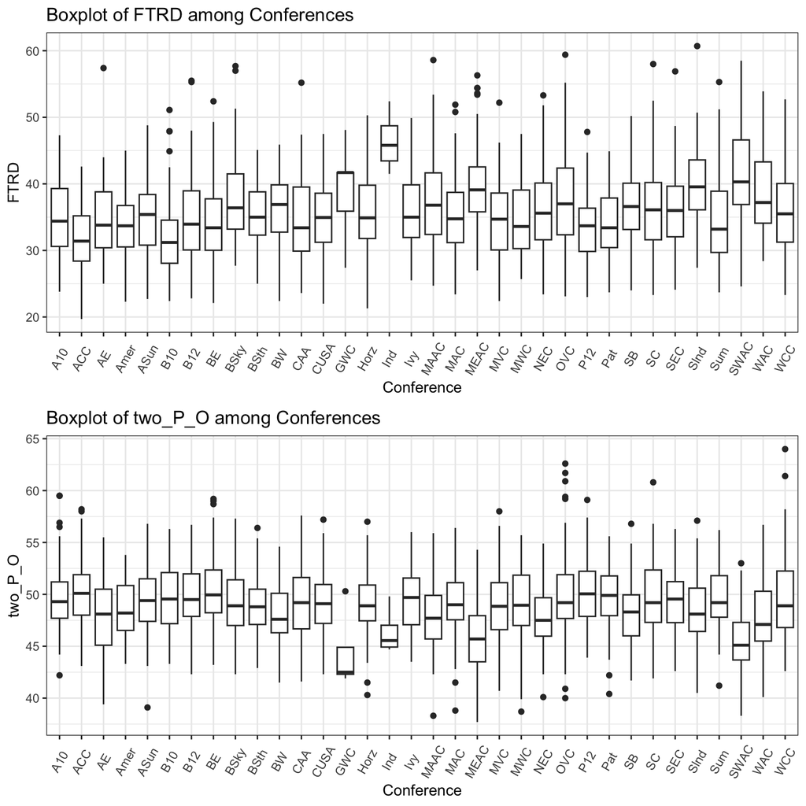

For these 4 boxplots, conferences GWC, MEAC, NEC, and SWAC and Ind group are likely to have higher values in `DRB`, `TORD`, and `FTRD` than other conferences in the first 3 boxplots while having lower values in `two_P_O` than other conferences shown by the last one.

The distributions of the remaining game performance indicators among conferences do not fluctuate much, so I did not include them in the analysis. Those game performance indicators mentioned above may be the reasons causing the differences in the `SEED` among the conferences, but further data analysis is still needed.

> Question 2: How can we predict a team’s `Seed` based on the its existing basketball game performance data of the regular season?

To develop the best approach for predicting the `SEED`, we wanted to create effective models that would indicate how the game performance indicators might be used to understand the patterns. Therefore, I calculated the correlation coefficients (r) of `SEED` and all the game performance indicators variables and utilized a scatterplot to display them as follows:

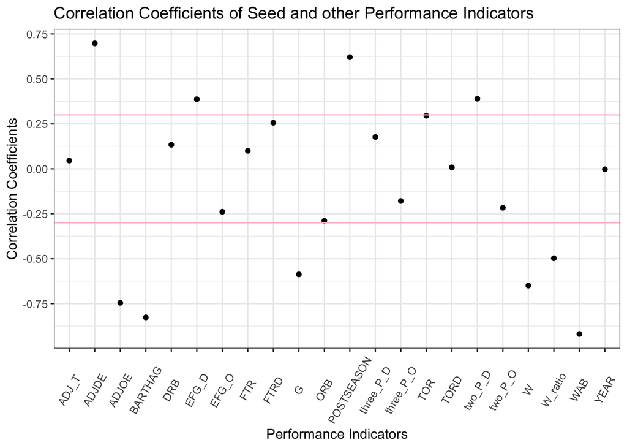

On the scatterplot, certain points draw my attention:

The variables strongly positively correlated to `SEED`: `ADJDE` (r= 0.697441023) and `POSTSEASON` (r= 0.62079851).

The variables strongly negatively correlated to `SEED`: `WAB` (r= -0.918860161), `BARTHAG` (r= -0.826583963), `ADJOE` (r= -0.745242957), and `W` (r= -0.649496188).

One interesting point is that the correlation coefficient of `SEED` and `YEAR` is -0.002698 (nearly 0, indicating that `YEAR` does not influence which teams get into finals.

I created 4 models for testing. The first model was empty and relied purely on the average `SEED` from 2013 to 2021 except 2020. The next model contained all predictors (all the game performance indicators). Using the *Both-direction Stepwise Model Selection* method on the full model, our third model picked the best predictors using AIC (AIC=346.59). Likewise, the last model was chosen from the modified *full model* mentioned above using the *Both-direction Stepwise Model Selection* method based on the AIC (AIC=334.78). The third model is -6.44869443+ -0.82091537* `WAB` + 8.24557772* `W_ratio` + 0.17145355* `two_P_D` + 15.13874804* `BARTHAG` + -0.30972253* `ADJOE` + 0.36305352* `ADJDE` + -0.07591390* `ADJ_T` + 0.03701627* `FTRD` + -0.13172055* `EFG_D`, while the last model is -4.33766090 + -0.82986380* `WAB` + 7.99275351* `W_ratio` + -0.07521933* `G` + -0.29202360* `ADJOE` + 14.16200872* `BARTHAG` + 0.33506762* `ADJDE`.

I did *Cross-Validation* on the original dataset, splitting the data into the training dataset and testing dataset with the ratio of 0.8:0.2. I built the models based on the training dataset and measured each model using mean average error (MAE) on the testing dataset. The results are shown in the table below:

Mean Average Error by Model

| Model | Mean_Average_Error |
| --- | --- |
| Empty | 4.05 |
| Full | 1.34 |
| Stepwise_both_1 | 1.33 |
| Stepwise_both_2 | 1.26 |

I notice that the last model is the most successful at minimizing errors in the testing data. For this model, the mean average error (MAE) is the lowest (MAE=1.26) compared to other models. To further compare each model’s performance of predicting the `SEED` on the training data, I draw *Predicted vs. Observed* plots as follows:

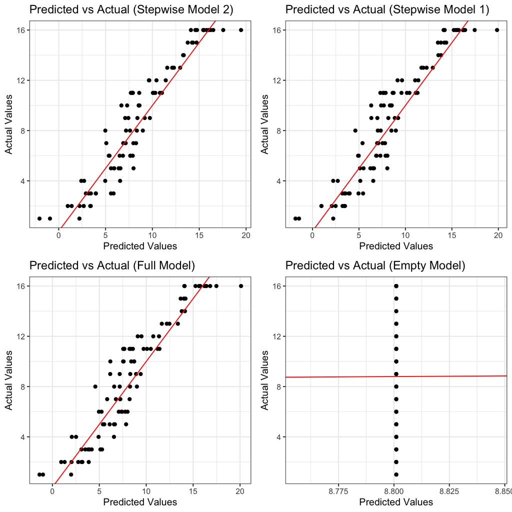

Although the first three plots look somewhat similar, we can roughly identify that the points in the first picture fit the red line (y=x) best, illustrating that the *Both-direction Stepwise Selection Model 2* (the last model mentioned above) performs the best at predicting the future `SEED` based on the existing data. And the model is -4.33766090 + -0.82986380* `WAB` + 7.99275351* `W_ratio` + -0.07521933* `G` + -0.29202360* `ADJOE` + 14.16200872* `BARTHAG` + 0.33506762* `ADJDE`.

# Conclusion

We have found that the basketball levels differ between conferences. Conferences like ACC, B10, B12, and BE have the strongest teams in the country, which are advantageous for making it to March Madness. However, conferences MEAC, NEC, SWAC, and GWC are in unfavorable situations. According to the results, the differences between conferences may be due to performance indicators such as Adjusted Offensive Efficiency, Adjusted Defensive Efficiency, Two-Point Shooting Percentage, Two-Point Shooting Percentage Allowed, Turnover Percentage Committed (Steal Rate), Offensive Rebound Rate Allowed, and Free Throw Rate Allowed. More data and analysis are required to explore which performance indicators are the primary influencing factors.

Additionally, we built a model to predict the *Seed*. The model indicates that `WAB`, `W_ratio`, `G`, `ADJOE`, `BARTHAG`, and `ADJDE` are the most important predictors. In practical applications, these results may help coaches to design training programs more accurately, taking into account the importance of Adjusted Offensive Efficiency and Adjusted Defensive Efficiency, and help the team reach a higher probability of breaking into the finals.